# Incarceration Analysis in United States Jails

Noah Hellyer

2/24/2022

## Introduction:

The purpose of analyzing this dataset was to find trends within the Incarceration data and use this to illustrate visual representation of these trends and to find key values from the data. This data shows Incarceration data from 1970-2018 in the United States and specifies it down to the state and then county level. I chose to focus on more recent data ranging from 2008 up until 2018 and many of my illustrations and key values focus on 2018 for the most recent data. I also wanted to narrow down the scope even more to the state of Washington because it shows trends in our local state and was most interesting to me as well.

## Summary Information:

```
## [1] 973360
```

##### The following values in the summary show the comparison of the amount of people in Washington by ethnicity and the the amount of people in jail by ethnicity. I then choseto find the proportion of people of these two numbers to determine if there are more percentage of people in jail for there given ethnicity compared to the white population in Washington. This calculation was interesting because it showed that Native Americans and Black people had a much higher chance of being in jail than white people but Asian Americans/Pacific Islanders and the Latinx population had a lower chance than white people to be in jail based on the amount for each ethnicity in Washingtons population.

##### Shows the Native American population jail difference to White population

```
## [1] 0.05886183
```

##### Shows the Black population jail difference to White population

```
## [1] 0.1740459
```

##### Shows the Latinx population jail difference to White population

```
## [1] -0.02468164
```

##### Shows the Asian American/Pacific Islander population jail difference to White population

```
## [1] -0.1195477
```

## Trends Over Time Chart, Line Graph

###### This graph shows how the inmate population broken down by ethnicity changes in the state of Washington from the years 2008-2018.

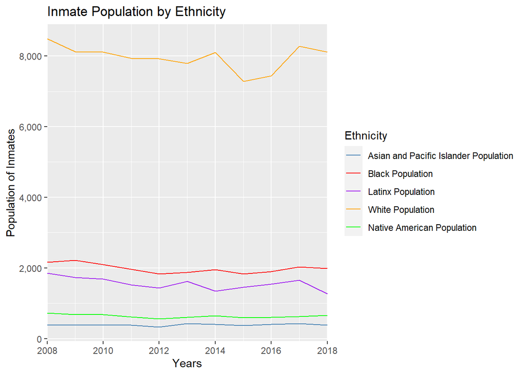

## Variable Comparison Chart, Scatter Plot and Trend Line

##### This graph shows how the jail capacity compares to the jail population admitted and displays the difference between these two values for each jail in a difference represented with a red dot.

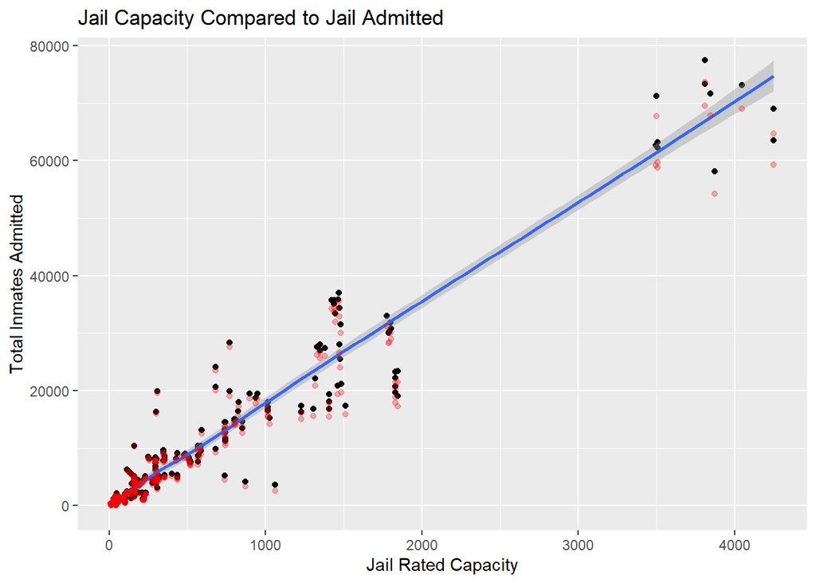

## Map, Jail population in WA by county in 2018

##### This map is useful to understand where people are in jail in the state of Washington and gives a good understanding of where jails are located. Something I didn’t realize until completing this map was that it really will also represent where the population is the densest.

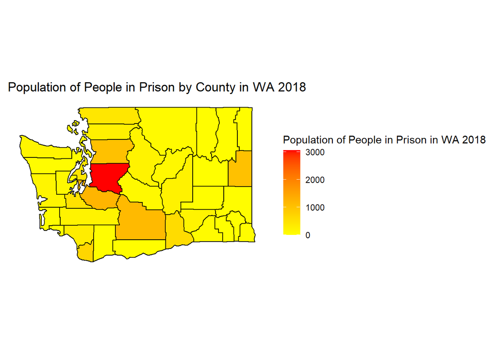